# 05_HGT.md

Gulnara Tagridzhanova

14/04/2025

## 1. Identify sequences in my genome annotations

- Downloaded sequences fro the putative HGT genes. Unfortunately they only uploaded them as nuclotide fastas, and I cannot find a way to transcribe them without getting floded by stop codons:
  - KF573967.1 Trebouxia decolorans clone contig_699 putative sulfite efflux pump/TDT transporter-like gene
  - KF573968.1 Trebouxia decolorans clone contig_18734 putative nitrilase-like gene
  - KF573969.1 Trebouxia decolorans clone contig_45971 putative oxidoreductase-like gene

#### GTX0536

- Blasted them against transcripts, got hight quality matches for 2 out of 3

```r
blastn -query analysis_and_temp_files/02_genome_annotation/hgt_genbank.fa -subject analysis_and_temp_files/02_genome_annotation/GTX0536_pred2/annotate_results/Trebouxia_sp._A48.mrna-transcripts.fa -evalue 1e-5 -outfmt 6

KF573967.1      GTX0536PRED_006449-T1   84.825  1140    162     6       878     2008    1358    221     0.0     1136
KF573969.1      GTX0536PRED_004195-T1   91.977  349     27      1       223     570     1085    737     1.36e-137       488
```

- Blasted them against purified assembly, got matches to the same proteins

```r
blastn -query analysis_and_temp_files/02_genome_annotation/hgt_genbank.fa -subject analysis_and_temp_files/02_genome_annotation/GTX0536_pred2/annotate_results/Trebouxia_sp._A48.scaffolds.fa -evalue 1e-5 -outfmt 6

KF573967.1      GTX0536_7       84.825  1140    162     6       878     2008    3865438 3864301 0.0     1136
KF573967.1      GTX0536_2       81.174  409     68      7       3306    3707    2812042 2811636 8.64e-86        320
KF573967.1      GTX0536_4       80.529  416     72      7       3305    3713    3708835 3709248 5.20e-83        311
KF573967.1      GTX0536_9       80.336  417     73      7       3304    3713    3299882 3300296 6.72e-82        307
KF573967.1      GTX0536_6       75.893  224     44      9       2469    2687    1661616 1661834 2.63e-21        106
KF573967.1      GTX0536_19      76.536  179     29      10      3383    3552    1684267 1684441 3.43e-15        86.1
KF573967.1      GTX0536_1       78.261  138     26      4       2520    2655    4223606 4223741 3.43e-15        86.1
KF573969.1      GTX0536_5       91.713  362     29      1       223     583     482970  483331  4.36e-141       501
```

- Blasted them against whole assembly with the same result

```r
blastn -query analysis_and_temp_files/02_genome_annotation/hgt_genbank.fa -subject analysis_and_temp_files/02_genome_annotation/GTX0536.fasta -evalue 1e-5 -outfmt 6

blastn -query analysis_and_temp_files/02_genome_annotation/hgt_genbank.fa -subject analysis_and_temp_files/02_genome_annotation/GTX0536.fasta -evalue 1e-5 -outfmt 6
KF573967.1      ptg000013l      84.825  1140    162     6       878     2008    3865438 3864301 0.0     1136
KF573967.1      ptg000012l      81.174  409     68      7       3306    3707    2812042 2811636 9.58e-86        320
KF573967.1      ptg000009l      80.529  416     72      7       3305    3713    3708835 3709248 5.76e-83        311
KF573967.1      ptg000015l      80.336  417     73      7       3304    3713    3299882 3300296 7.46e-82        307
KF573967.1      ptg000017l      75.893  224     44      9       2469    2687    1661616 1661834 2.92e-21        106
KF573967.1      ptg000011l      76.536  179     29      10      3383    3552    1684267 1684441 3.80e-15        86.1
KF573967.1      ptg000002l      78.261  138     26      4       2520    2655    4223606 4223741 3.80e-15        86.1
KF573969.1      ptg000010l      91.713  362     29      1       223     583     482970  483331  4.84e-141       501
```

#### SL000003

- Blasted agains mrna: nothing

```r
blastn -query analysis_and_temp_files/02_genome_annotation/hgt_genbank.fa -subject analysis_and_temp_files/02_genome_annotation/SL0000003_pred/annotate_results/Trebouxia_SL0000003_SL0000003.mrna-transcripts.fa  -evalue 1e-3 -outfmt 6
```

- Blasted against scafflods, got sequences for KF573967.1

```r
blastn -query analysis_and_temp_files/02_genome_annotation/hgt_genbank.fa -subject analysis_and_temp_files/02_genome_annotation/SL0000003_pred/annotate_results/Trebouxia_SL0000003_SL0000003.scaffolds.fa  -evalue 1e-3 -outfmt 6

KF573967.1      scaffold_14     93.352  1444    91      5       803     2243    501038  499597  0.0     2130
KF573967.1      scaffold_3      83.446  296     35      9       3383    3670    3033618 3033329 1.36e-68        263
KF573967.1      scaffold_7      81.570  293     44      7       3388    3671    1684351 1684060 1.07e-59        233
KF573967.1      scaffold_10     78.077  260     30      15      3304    3553    408525  408283  2.39e-31        139
KF573967.1      scaffold_15     75.115  217     47      7       2474    2687    257738  257526  5.25e-18        95.3
```

- It appears this gene wasn’t annotated. Blasted the protein from my assembly against SL0000003, isolated the match and translated it to get the protein sequence

```r
samtools faidx analysis_and_temp_files/02_genome_annotation/GTX0536_pred2/annotate_results/Trebouxia_sp._A48.proteins.fa GTX0536PRED_006449-T1 >  analysis_and_temp_files/05_HGT/GTX0536PRED_006449.faa

tblastn -query analysis_and_temp_files/05_HGT/GTX0536PRED_006449.faa -subject analysis_and_temp_files/02_genome_annotation/SL0000003_pred/annotate_results/Trebouxia_SL0000003_SL0000003.scaffolds.fa -outfmt 6
GTX0536PRED_006449-T1   scaffold_14     79.949  389     77      1       1       389     499810  500973  0.0     599
GTX0536PRED_006449-T1   scaffold_14     39.577  331     192     2       28      353     764443  763460  9.89e-52        187
GTX0536PRED_006449-T1   scaffold_14     45.588  68      32      2       291     354     763656  763456  3.89e-08        56.6
GTX0536PRED_006449-T1   scaffold_12     28.750  80      47      4       96      165     1819668 1819907 2.1     31.6
GTX0536PRED_006449-T1   scaffold_20     37.931  29      18      0       28      56      141652  141566  5.4     30.4

samtools faidx analysis_and_temp_files/02_genome_annotation/SL0000003_pred/annotate_results/Trebouxia_SL0000003_SL0000003.scaffolds.fa scaffold_14:499810-500973 > analysis_and_temp_files/05_HGT/SL0000003_GTX0536PRED_006449.fa
```

## 2. Blasted the protein sequences against NCBI

- For both GTX0536PRED_006449-T1 and GTX0536PRED_004195-T1, blasted them against NCBI nt and nr, saves both results as csv. For nr, also saved as faa
- For the same proteins, ran the search against nr excluding fungi -> saved csv and faa
- For the same proteins, ran the search against nr including only Viridiplanta -> saved csv and faa

## 3. Visualize scores

- Pull together all hits and filter to include only hits with >75% query cover
- Define a funciton to do this

```r
library(stringr)
library(tidyverse)
library(taxize)
library(RColorBrewer)

analyze_blast  <- function(d){
  d <- d  %>%
  mutate(ID = str_match(Accession, "gov\\/.*\\/(.*?)\\?report")[,2],
         cover = as.numeric(str_replace(Query.Cover,"%",""))) %>%
  filter(cover>75)
  d$Per..ident<-as.numeric(d$Per..ident)

#get taxid for each hit based on its accession ID
get_taxid <- function(x){
df <- data.frame("accession"=x,"taxid"=genbank2uid(id = x,key="86df5e42e9751ae03c5e114326c1740ef008")[[1]][1])
return(df)}

l<-lapply(d$ID,get_taxid)
acc_taxid <- do.call(rbind,l)
acc_taxid <- acc_taxid %>% filter(!is.na(taxid),taxid!="") %>% distinct()

#get taxonomy for each taxid
get_taxonomy<- function(x){
  df <- classification(x,db="ncbi",key="86df5e42e9751ae03c5e114326c1740ef008")[[1]]
  df <- df %>% filter(rank %in% c("kingdom","phylum","class","order","family","genus")) %>% select(-id) %>% mutate(taxid=x)
  return(df)}
l2<-lapply(unique(acc_taxid$taxid),get_taxonomy)
taxonomy <- do.call(rbind,l2)
taxonomy <- taxonomy %>% pivot_wider(names_from=rank,values_from=name)

#combine
d <- d %>% left_join(acc_taxid,by=c("ID"="accession")) %>%
  left_join(taxonomy) %>% filter(!is.na(taxid))
return(d)}
```

- Visualize both genes nr and nt separately

```r
nr_6449 <- rbind(read.csv2("../analysis_and_temp_files/05_HGT/GTX0536PRED_006449_nr.csv",sep=","),
      read.csv2("../analysis_and_temp_files/05_HGT/GTX0536PRED_006449_nr_no_fungi.csv",sep=","),
      read.csv2("../analysis_and_temp_files/05_HGT/GTX0536PRED_006449_nr_viridiplanta.csv",sep=","))

nr_6449 <- analyze_blast(nr_6449)
nr_6449$database <- "nr"
nr_6449$gene <- "GTX0536PRED_006449"


nt_6449 <- rbind(read.csv2("../analysis_and_temp_files/05_HGT/GTX0536PRED_006449_nt.csv",sep=","),
      read.csv2("../analysis_and_temp_files/05_HGT/GTX0536PRED_006449_nt_no_fungi.csv",sep=","),
      read.csv2("../analysis_and_temp_files/05_HGT/GTX0536PRED_006449_nt_viridiplanta.csv",sep=","))

nt_6449 <- analyze_blast(nt_6449)
nt_6449$database <- "nt"
nt_6449$gene <- "GTX0536PRED_006449"


nr_4195 <- rbind(read.csv2("../analysis_and_temp_files/05_HGT/GTX0536PRED_004195_nr.csv",sep=","),
      read.csv2("../analysis_and_temp_files/05_HGT/GTX0536PRED_004195_nr_no_fungi.csv",sep=","),
      read.csv2("../analysis_and_temp_files/05_HGT/GTX0536PRED_004195_nr_viridiplanta.csv",sep=","))

nr_4195 <- analyze_blast(nr_4195)
nr_4195$database <- "nr"
nr_4195$gene <- "GTX0536PRED_004195"

nt_4195 <- rbind(read.csv2("../analysis_and_temp_files/05_HGT/GTX0536PRED_004195_nt.csv",sep=","),
      read.csv2("../analysis_and_temp_files/05_HGT/GTX0536PRED_004195_nt_no_fungi.csv",sep=","),
      read.csv2("../analysis_and_temp_files/05_HGT/GTX0536PRED_004195_nt_viridiplanta.csv",sep=","))

nt_4195 <- analyze_blast(nt_4195)
```

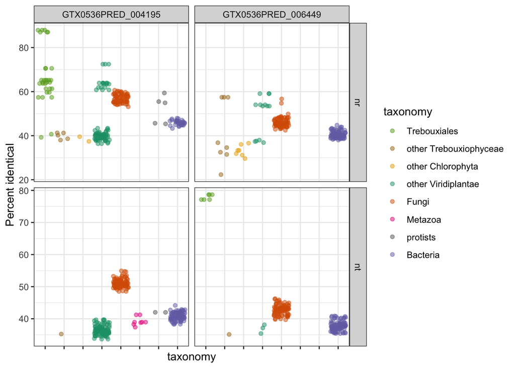

```r
nt_4195$database <- "nt"
nt_4195$gene <- "GTX0536PRED_004195"

all <- rbind(nt_4195,nr_4195,nt_6449,nr_6449)


all <- all %>%
  mutate(taxonomy = case_when(order=="Trebouxiales" ~ order,
    class=="Trebouxiophyceae"& order!="Trebouxiales" ~ "other Trebouxiophyceae",
       phylum == "Chlorophyta" & class!="Trebouxiophyceae" ~ "other Chlorophyta",
      kingdom == "Fungi" ~ kingdom,
     kingdom == "Viridiplantae" ~ "other Viridiplantae",
     phylum == "Rhodophyta" ~ "other Viridiplantae",
    kingdom == "Metazoa" ~ kingdom ,
    class=="Filasterea" | phylum== "Heterolobosea" |  phylum=="Evosea" ~ "protists",
     kingdom %in% c("Pseudomonadati","Thermotogati","Bacillati") |
      class=="Deltaproteobacteria"~ "Bacteria"))

all$taxonomy <- factor(all$taxonomy,levels=c("Trebouxiales","other Trebouxiophyceae","other Chlorophyta","other Viridiplantae","Fungi","Metazoa","protists","Bacteria"))


ggplot(all,aes(color=taxonomy,x=taxonomy,y=Per..ident))+
  geom_jitter(alpha=.5) +
  scale_color_manual(values=c("Trebouxiales" = brewer.pal(8,"Dark2")[5],
  "other Chlorophyta" = brewer.pal(8,"Dark2")[6],
  "other Viridiplantae" = brewer.pal(8,"Dark2")[1],
  "Fungi" = brewer.pal(8,"Dark2")[2],
  "Bacteria" = brewer.pal(8,"Dark2")[3],
  "other Trebouxiophyceae" = brewer.pal(8,"Dark2")[7],
  "Metazoa"=brewer.pal(8,"Dark2")[4],
  "protists"=brewer.pal(8,"Dark2")[8]))+
  facet_grid(database~gene,scales="free_y")+
  theme_bw()+ylab("Percent identical")+
  theme(axis.text.x = element_blank())
```

```r
ggsave("../results/hgt_blast.pdf",width=5,height=2.5)
```

## 4. Phylogeny

- Opened the fasta files and wrote filtered versions that only include sequences with >75% query coever and for which we got taxonomy

```r
library(Biostrings)
faa_6449 <- c(readAAStringSet("../analysis_and_temp_files/05_HGT/GTX0536PRED_006449_nr.faa"),
      readAAStringSet("../analysis_and_temp_files/05_HGT/GTX0536PRED_006449_nr_no_fungi.faa"),
      readAAStringSet("../analysis_and_temp_files/05_HGT/GTX0536PRED_006449_nr_viridiplanta.faa"))
names(faa_6449) <- sub("\\s.*", "",names(faa_6449))
faa_6449_filtered <- faa_6449[names(faa_6449) %in% nr_6449$ID] %>% unique()

faa_4195 <- c(readAAStringSet("../analysis_and_temp_files/05_HGT/GTX0536PRED_004195_nr.faa"),
      readAAStringSet("../analysis_and_temp_files/05_HGT/GTX0536PRED_004195_nr_no_fungi.faa"),
      readAAStringSet("../analysis_and_temp_files/05_HGT/GTX0536PRED_004195_nr_viridiplanta.faa"))
names(faa_4195) <- sub("\\s.*", "",names(faa_4195))
faa_4195_filtered <- faa_4195[names(faa_4195) %in% nr_4195$ID] %>% unique()

writeXStringSet(faa_4195_filtered,"../analysis_and_temp_files/05_HGT/GTX0536PRED_004195_genbank.faa")
writeXStringSet(faa_6449_filtered,"../analysis_and_temp_files/05_HGT/GTX0536PRED_006449_genbank.faa")
```

- Save the tables for supplementary

```r
all_save<- all %>% select(gene,database,ID,Description,Scientific.Name,
    Max.Score,E.value,Per..ident,cover,taxid,kingdom,phylum,class,order,family,
    genus,taxonomy ) %>% distinct()
write.table(all_save, "../results/hgt_blast.txt",col.names = T, row.names = F, quote = F,sep="\t")
```

- Combine together genbank sequences with sequences from my two genomes

```r
cat analysis_and_temp_files/05_HGT/GTX0536PRED_006449_genbank.faa analysis_and_temp_files/05_HGT/SL0000003_GTX0536PRED_006449.faa analysis_and_temp_files/05_HGT/GTX0536PRED_006449.faa > analysis_and_temp_files/05_HGT/GTX0536PRED_006449_all.faa

samtools faidx analysis_and_temp_files/02_genome_annotation/GTX0536_pred2/annotate_results/Trebouxia_sp._A48.proteins.fa GTX0536PRED_004195-T1 >  analysis_and_temp_files/05_HGT/GTX0536PRED_004195_all.faa

cat analysis_and_temp_files/05_HGT/GTX0536PRED_004195_genbank.faa >> analysis_and_temp_files/05_HGT/GTX0536PRED_004195_all.faa
```

- Align

```r
source package /tgac/software/testing/bin/mafft-7.271
source package /tsl/software/testing/bin/trimal-latest
source package /tgac/software/testing/bin/gcc-4.9.1

mafft --maxiterate 1000 --genafpair --thread 10  analysis_and_temp_files/05_HGT/GTX0536PRED_006449_all.faa >  analysis_and_temp_files/05_HGT/GTX0536PRED_006449_aligned.faa

trimal -in analysis_and_temp_files/05_HGT/GTX0536PRED_006449_aligned.faa -out analysis_and_temp_files/05_HGT/GTX0536PRED_006449_aligned.phyl -gt 0.2 -phylip  -keepheader

mafft --maxiterate 1000 --genafpair --thread 10  analysis_and_temp_files/05_HGT/GTX0536PRED_004195_all.faa >  analysis_and_temp_files/05_HGT/GTX0536PRED_004195_aligned.faa

trimal -in analysis_and_temp_files/05_HGT/GTX0536PRED_004195_aligned.faa -out analysis_and_temp_files/05_HGT/GTX0536PRED_004195_aligned.phyl -gt 0.2 -phylip  -keepheader
```

- Tree with IQTree

```r
source package /tgac/software/testing/bin/iqtree-2.2.2.2

iqtree2 -s analysis_and_temp_files/05_HGT/GTX0536PRED_006449_aligned.phyl  -B 10000 -T AUTO --threads-max 20

iqtree2 -s analysis_and_temp_files/05_HGT/GTX0536PRED_004195_aligned.phyl  -B 10000 -T AUTO --threads-max 20
```

- Rename

```r
library(ape)
library(ggtree)
tree1<-read.tree("../analysis_and_temp_files/05_HGT/GTX0536PRED_006449_aligned.phyl.contree")

nr_6449$name <- paste(nr_6449$ID,nr_6449$kingdom,nr_6449$phylum,
                      nr_6449$class,nr_6449$order)

tree1$tip.label<-nr_6449[[20]][match(tree1$tip.label, nr_6449[[10]])]
ape::write.tree(tree1, file="../analysis_and_temp_files/05_HGT/GTX0536PRED_006449_aligned.phyl.renamed.contree")

tree2<-read.tree("../analysis_and_temp_files/05_HGT/GTX0536PRED_004195_aligned.phyl.contree")

nr_4195$name <- paste(nr_4195$ID,nr_4195$kingdom,nr_4195$phylum,
                      nr_4195$class,nr_4195$order)

tree2$tip.label<-nr_4195[[20]][match(tree2$tip.label, nr_4195[[10]])]
ape::write.tree(tree2, file="../analysis_and_temp_files/05_HGT/GTX0536PRED_004195_aligned.phyl.renamed.contree")
```

## 5. Check neighboring genes

- Upstream of GTX0536PRED_006449 is GTX0536PRED_006448
- Upstream of GTX0536PRED_004195 is GTX0536PRED_004194
- Blasted against nt and nr (all-inclusive)
- Plotted the same way

```r
nr_6448 <- read.csv2("../analysis_and_temp_files/05_HGT/GTX0536PRED_006448_nr.csv",sep=",")

nr_6448 <- analyze_blast(nr_6448)
nr_6448$database <- "nr"
nr_6448$gene <- "GTX0536PRED_006448"


nt_6448 <- read.csv2("../analysis_and_temp_files/05_HGT/GTX0536PRED_006448_nt.csv",sep=",")

nt_6448 <- analyze_blast(nt_6448)
nt_6448$database <- "nt"
nt_6448$gene <- "GTX0536PRED_006448"


nr_4194 <- read.csv2("../analysis_and_temp_files/05_HGT/GTX0536PRED_004194_nr.csv",sep=",")

nr_4194 <- analyze_blast(nr_4194)
nr_4194$database <- "nr"
nr_4194$gene <- "GTX0536PRED_004194"

nt_4194 <- read.csv2("../analysis_and_temp_files/05_HGT/GTX0536PRED_004194_nt.csv",sep=",")

nt_4194 <- analyze_blast(nt_4194)
```

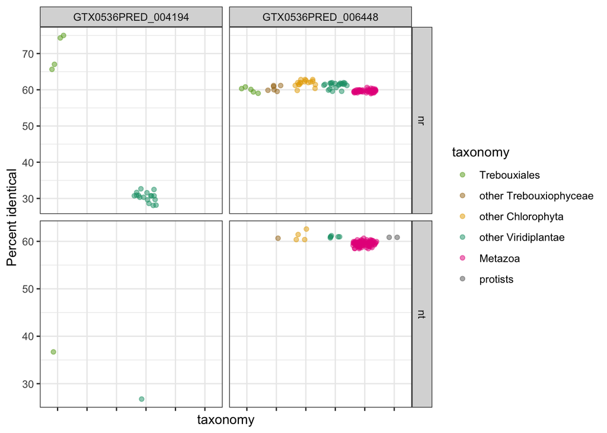

```r
nt_4194$database <- "nt"
nt_4194$gene <- "GTX0536PRED_004194"

all2 <- rbind(nt_4194,nr_4194,nt_6448,nr_6448)


all2 <- all2 %>%
  mutate(taxonomy = case_when(order=="Trebouxiales" ~ order,
    class=="Trebouxiophyceae"& order!="Trebouxiales" ~ "other Trebouxiophyceae",
       phylum == "Chlorophyta" & class!="Trebouxiophyceae" ~ "other Chlorophyta",
      kingdom == "Fungi" ~ kingdom,
     kingdom == "Viridiplantae" ~ "other Viridiplantae",
     phylum == "Rhodophyta" ~ "other Viridiplantae",
    kingdom == "Metazoa" ~ kingdom ,
    class=="Filasterea" | phylum %in% c("Heterolobosea" ,"Evosea", "Oomycota") ~ "protists",
     kingdom %in% c("Pseudomonadati","Thermotogati","Bacillati") |
      class=="Deltaproteobacteria"~ "Bacteria"))

all2$taxonomy <- factor(all2$taxonomy,levels=c("Trebouxiales","other Trebouxiophyceae","other Chlorophyta","other Viridiplantae","Fungi","Metazoa","protists","Bacteria"))


ggplot(all2 %>% filter(!is.na(taxonomy)),aes(color=taxonomy,x=taxonomy,y=Per..ident))+
  geom_jitter(alpha=.5) +
  scale_color_manual(values=c("Trebouxiales" = brewer.pal(8,"Dark2")[5],
  "other Chlorophyta" = brewer.pal(8,"Dark2")[6],
  "other Viridiplantae" = brewer.pal(8,"Dark2")[1],
  "Fungi" = brewer.pal(8,"Dark2")[2],
  "Bacteria" = brewer.pal(8,"Dark2")[3],
  "other Trebouxiophyceae" = brewer.pal(8,"Dark2")[7],
  "protists"=brewer.pal(8,"Dark2")[8],
  "Metazoa"=brewer.pal(8,"Dark2")[4]))+
  facet_grid(database~gene,scales="free_y")+
  theme_bw()+ylab("Percent identical")+
  theme(axis.text.x = element_blank())
```

```r
ggsave("../results/neighbor_blast.pdf",width=5,height=2.5)
```